# Final project STAT5060

2023-11-23

# Data Introduction

The dataset “Nurses.csv” contains data from a cross-sectional hypothetical study on stress experienced by nurses in hospitals. In each of 25 hospitals, four wards were selected and randomly assigned to an experimental or control condition, where the intervention included a training program to cope with job-related stress. After the intervention was implemented, a random sample of 10 nurses from each ward completed a survey to test job-related stress level.

Variables in the dataset:

*hospital*: ID number for a hospital $(1, \ldots, 25)$, a total of 25 hospitals

*ward*: ward numbering within a hospital $(1,2,3,4)$, a total of 4 wards from each hospital

*wardid*: ID number of ward (not used in programming of analyses)

*nurse*: ID number for a nurse $(1, \ldots, 1000)$, a total of 1000 nurses (not used in programming)

*age*: nurse’s age in years gender: nurse’s gender $(0=$ male, $1=$ female $)$

*experience*: nurse’s years of experience working stress: outcome variable, a scale from 1 to 7

*wardtype*: type of hospital ward (‘general care’, ‘special care’)

*hospize*: hospital size (‘small’, ‘medium’, ‘large’)

*expcon*: intervention indicator variable (‘control’, ‘experiment’) administered at Ward

# Basic data manipulations

```r
library(ggplot2)
library(nlme)
library(lme4)
library(mgcv)
library(readr)
library(furniture)    # nice table1() descriptives
library(stargazer)    # display nice tables: summary & regression
library(tidyverse)
library(dplyr)
dat <- read_csv("./Nurses.csv")
dat[dat$hospsize == "small", 12] <- 0
dat[dat$hospsize == "medium", 12] <- 1
dat[dat$hospsize == "large", 12] <- 2
colnames(dat)[12] <- "nhospsize"
dat$c.nhospsize <- dat$nhospsize - 1

dat[dat$wardtype == "general care", 14] <- 0
dat[dat$wardtype == "special care", 14] <- 1
colnames(dat)[14] <- "nwardtype"

dat[dat$expcon == "control", 15] <- 0
dat[dat$expcon == "experiment", 15] <- 1
colnames(dat)[15] <- "nexpcon"
dat$c.nexpcon <- dat$nexpcon - 0.5

dat$c.age <- dat$age - mean(dat$age)
dat$c.experience <- dat$experience - mean(dat$experience)
dat
```

| hospital | ward | wardid | nurse | age | gender | experience | stress | wardtype | hospsize | expcon | nhospsize | c.nhospsize | nwardtype | nexpcon | c.nexpcon | c.age | c.experience |
| --- | --- | --- | --- | --- | --- | --- | --- | --- | --- | --- | --- | --- | --- | --- | --- | --- | --- |
| 1 | 1 | 11 | 1 | 36 | 0 | 11 | 7 | general care | large | experiment | 2 | 1 | 0 | 1 | 0.5 | -7.005 | -6.057 |
| 1 | 1 | 11 | 2 | 45 | 0 | 20 | 7 | general care | large | experiment | 2 | 1 | 0 | 1 | 0.5 | 1.995 | 2.943 |
| 1 | 1 | 11 | 3 | 32 | 0 | 7 | 7 | general care | large | experiment | 2 | 1 | 0 | 1 | 0.5 | -11.005 | -10.057 |
| 1 | 1 | 11 | 4 | 57 | 1 | 25 | 6 | general care | large | experiment | 2 | 1 | 0 | 1 | 0.5 | 13.995 | 7.943 |
| 1 | 1 | 11 | 5 | 46 | 1 | 22 | 6 | general care | large | experiment | 2 | 1 | 0 | 1 | 0.5 | 2.995 | 4.943 |
| 1 | 1 | 11 | 6 | 60 | 1 | 22 | 6 | general care | large | experiment | 2 | 1 | 0 | 1 | 0.5 | 16.995 | 4.943 |
| 1 | 1 | 11 | 7 | 23 | 1 | 13 | 6 | general care | large | experiment | 2 | 1 | 0 | 1 | 0.5 | -20.005 | -4.057 |
| 1 | 1 | 11 | 8 | 32 | 1 | 13 | 7 | general care | large | experiment | 2 | 1 | 0 | 1 | 0.5 | -11.005 | -4.057 |
| 1 | 1 | 11 | 9 | 60 | 0 | 17 | 7 | general care | large | experiment | 2 | 1 | 0 | 1 | 0.5 | 16.995 | -0.057 |
| 1 | 2 | 12 | 10 | 45 | 0 | 21 | 6 | special care | large | experiment | 2 | 1 | 1 | 1 | 0.5 | 1.995 | 3.943 |

[output cut: 990 more lines]

# Exploratory Data Analysis

## Summarize Descriptive Statistics

```r
dat %>%
  data.frame() %>%
  stargazer::stargazer(title  = "Descriptive statistics, aggregate over entire sample",
                       header = FALSE,
                       type = "text")
```

```
##
## Descriptive statistics, aggregate over entire sample
## ==================================================
## Statistic      N    Mean   St. Dev.   Min    Max
## --------------------------------------------------
## hospital     1,000 13.016   6.947      1      25
## ward         1,000  2.493   1.119      1      4
## wardid       1,000 132.653  69.476    11     254
## nurse        1,000 500.500 288.819     1    1,000
## age          1,000 43.005   12.042    23      64
## gender       1,000  0.735   0.442      0      1
## experience   1,000 17.057   6.042      1      38
## stress       1,000  4.977   0.980      1      7
## nhospsize    1,000  0.776   0.689      0      2
## c.nhospsize  1,000 -0.224   0.689     -1      1
## nwardtype    1,000  0.501   0.500      0      1
## nexpcon      1,000  0.504   0.500      0      1
## c.nexpcon    1,000  0.004   0.500   -0.500  0.500
## c.age        1,000 -0.000   12.042  -20.005 20.995
## c.experience 1,000  0.000   6.042   -16.057 20.943
## --------------------------------------------------
```

```r
dat %>%
  furniture::table1(age, gender, experience, wardtype, hospsize, nhospsize, c.nhospsize,
                    splitby    = ~ expcon,                                              # var to divide sample by
                    test       = TRUE,                                                  # test groups different?
                    type       = "full",                                                # give the test statistic
                    output     = "text",                                                # output for html
                    caption    = "Compare Intervention groups on five main variables")  # title
```

```
## Breusch-Pagan Test of Heteroskedasticity suggests `var.equal = FALSE` in t.test() for: age
```

```
##
##  Compare Intervention groups on five main variables
```

```
##
## ──────────────────────────────────────────────────────────────────
##                                 expcon
##                  control     experiment  Test             P-Value
##                  n = 496     n = 504
##  age                                     T-Test: 0.82     0.411
##                  43.3 (11.6) 42.7 (12.5)
##  gender                                  T-Test: -0.51    0.61
##                  0.7 (0.4)   0.7 (0.4)
##  experience                              T-Test: 0.69     0.492
##                  17.2 (5.8)  16.9 (6.3)
##  wardtype                                Chi Square: 0    1
##     general care 247 (49.8%) 252 (50%)
##     special care 249 (50.2%) 252 (50%)
##  hospsize                                Chi Square: 0.01 0.993
##     large        74 (14.9%)  76 (15.1%)
##     medium       237 (47.8%) 239 (47.4%)
##     small        185 (37.3%) 189 (37.5%)
##  nhospsize                               T-Test: 0.01     0.992
##                  0.8 (0.7)   0.8 (0.7)
##  c nhospsize                             T-Test: 0.01     0.992
##                  -0.2 (0.7)  -0.2 (0.7)
## ──────────────────────────────────────────────────────────────────
```

## Identify the model for the marginal mean of stress

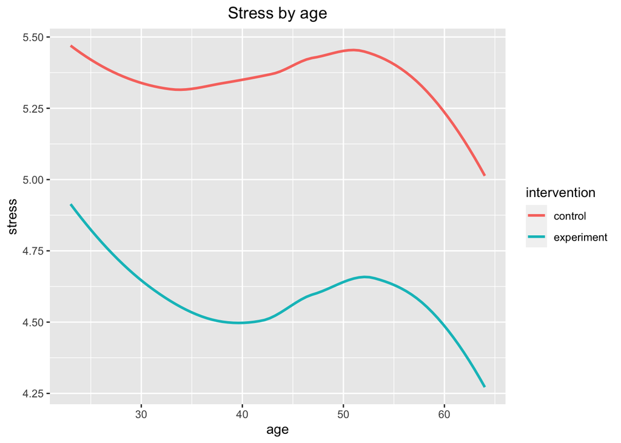

```r
p1<- ggplot(dat, aes(x=age, y=stress, group=expcon))
p1 = p1+geom_smooth(method="loess", se=F, aes(color=expcon))+
 labs(title="Stress by age",color="intervention") + theme(plot.title = element_text(hjust = 0.5))
p1
```

The stress levels of both the control and experiment groups appear to have a cubic relationship with the age of the nurse. Initially, stress levels decrease and then increase. However, after the age of 52, stress levels for both groups decrease until the end. It seems that the intervention has no moderating effect on the relationship between stress and nurse’s age, as the trend is consistent across both groups.

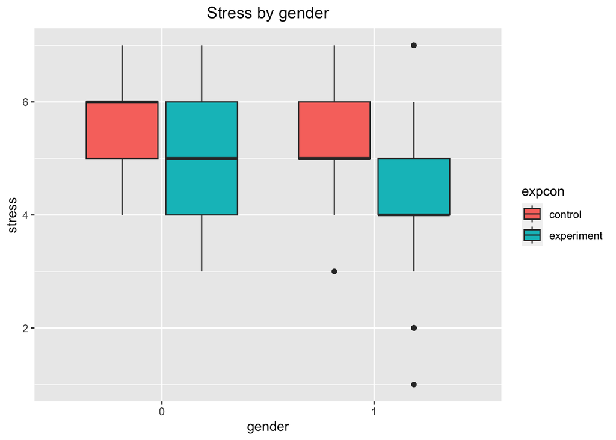

```r
dat$gender<-as.factor(dat$gender)
p2<- ggplot(dat, aes(x=gender, y=stress, fill=expcon))
p2 = p2+geom_boxplot()+labs(title="Stress by gender",color="intervention") + theme(plot.title = element_text(hjust = 0.5))
p2
```

According to the box plots, the average stress levels of female nurses are lower than those of male nurses in both the control and experimental groups. However, the difference is smaller in the control group. There is a moderating effect of intervention on the association between stress and nurse’s gender, because the outcome is different with intervention.

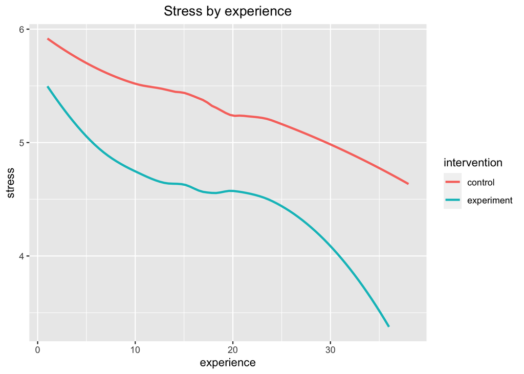

```r
p3 <- ggplot(dat, aes(x=experience, y=stress, group=expcon))
p3 = p3 + geom_smooth(method="loess", se=F, aes(color=expcon))+labs(title="Stress by experience",color="intervention")  + theme(plot.title = element_text(hjust = 0.5))
p3
```

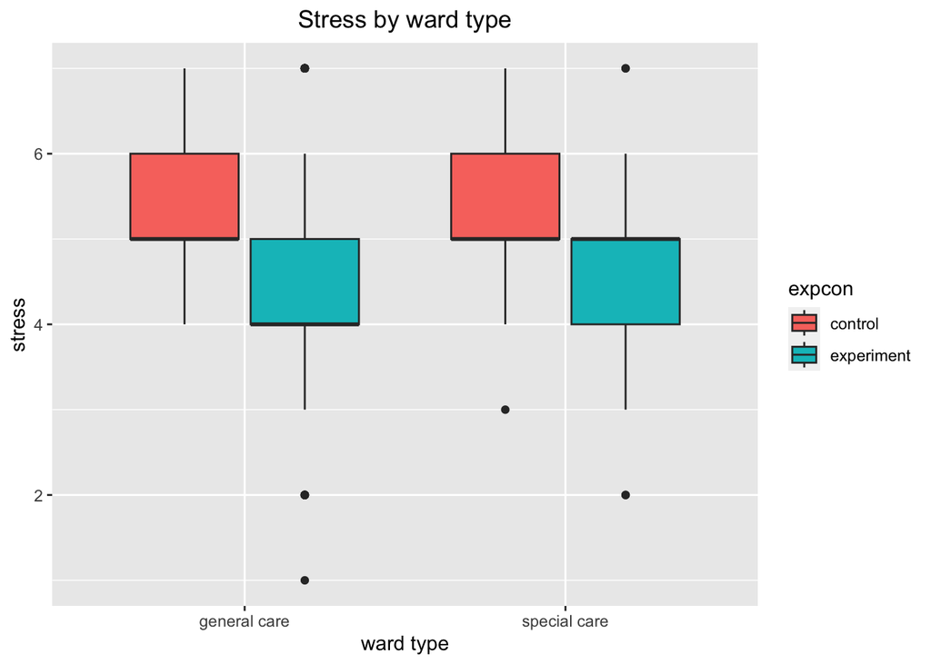

```r
p4<- ggplot(dat, aes(x=wardtype, y=stress, fill=expcon))
p4 = p4+geom_boxplot()+labs(title="Stress by ward type",color="intervention", x="ward type") + theme(plot.title = element_text(hjust = 0.5))
p4
```

In the control group, there seems to be no correlation between stress and the type of hospital ward. However, in the experiment group, the stress level among nurses in special care appears to be slightly higher. There seems to be a moderating effect of intervention on the relationship between stress and the type of hospital ward, as the effect of the experiment group is different from that of the control group.

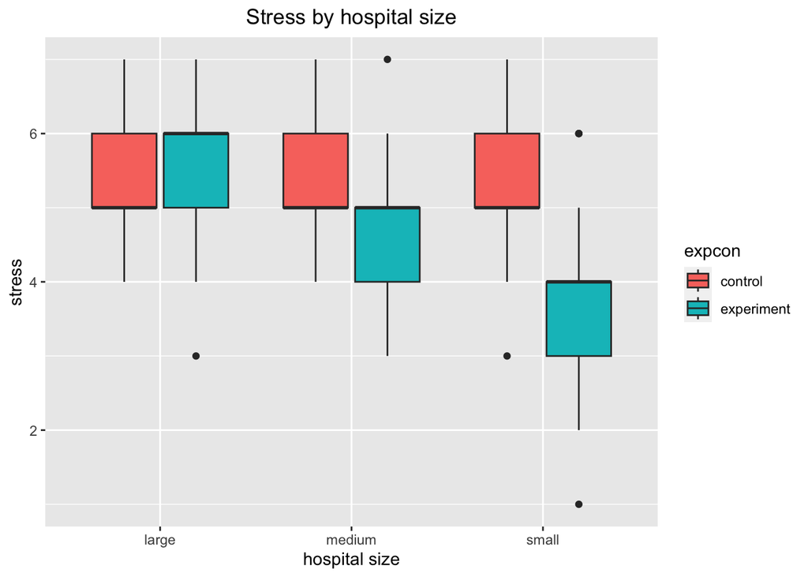

```r
p5 <- ggplot(dat, aes(x=hospsize, y=stress, fill=expcon))
p5 = p5 + geom_boxplot() + labs(title="Stress by hospital size",color="intervention", x="hospital size") + theme(plot.title = element_text(hjust = 0.5))
p5
```

In the control group, there appears to be no correlation between stress and hospital size. However, in the experiment group, there is a relationship between stress and hospital size. Since the association between stress and hospital size varies across the control and experiment groups, it seems that there is a moderating effect of intervention on the relationship between stress and hospital size.

# Multilevel models

## First model

Outcome is stress of nurse i in ward j of hospital k. We regress on the centered intervention indicator variable, centered nurse’s age, nurse’s gender, centered nurse’s experience in years, numerical variable for ward type, centered numerical variable for hospital size, and interaction between centered intervention indicator variable with centered numerical variable for hospital size, using only a random intercept at each appropriate level of hierarchy.

$$\begin{gathered}
Y_{i j k}=\beta_{000}+b_{0 k}+b_{0 j k}+\beta_{100} x_2+\beta_{200} x_3+
+\beta_{300} x_4+\beta_{010} x_1+\beta_{020} x_5+\beta_{001}
x_6+\beta_{011} x_1 x_6+\varepsilon_{i j k} \\
\gamma_{1 j k}=\beta_{100}, \gamma_{2 j k}=\beta_{200}, \gamma_{3 j
k}=\beta_{300}, \gamma_{1 j k}=\beta_{100},\\
\gamma_{01 k}=\beta_{010}+\beta_{011} x_6, \gamma_{02 k}=\beta_{020}, \\
\gamma_{001}=\beta_{001}.
\end{gathered}$$

```r
attach(dat)
ctrl <- lmeControl(opt='optim')
#model
m1 <- lme(stress~ c.nexpcon+c.age+gender+c.experience+nwardtype+c.nhospsize+c.nexpcon *c.nhospsize,random =~1 | hospital/ward, data=dat, na.action=na.omit, method="ML")

summary(m1)
```

```
## Linear mixed-effects model fit by maximum likelihood
##   Data: dat
##        AIC      BIC   logLik
##   1580.644 1634.629 -779.322
##
## Random effects:
##  Formula: ~1 | hospital
##         (Intercept)
## StdDev:   0.3700174
##
##  Formula: ~1 | ward %in% hospital
##         (Intercept)  Residual
## StdDev:   0.4098161 0.4654423
##
## Fixed effects:  stress ~ c.nexpcon + c.age + gender + c.experience + nwardtype +      c.nhospsize + c.nexpcon * c.nhospsize
##                           Value  Std.Error  DF   t-value p-value
## (Intercept)            5.399925 0.10306716 897  52.39229  0.0000
## c.nexpcon             -0.500064 0.09117741  72  -5.48451  0.0000
## c.age                  0.022272 0.00220183 897  10.11538  0.0000
## gender1               -0.454274 0.03499847 897 -12.97984  0.0000
## c.experience          -0.061873 0.00447392 897 -13.82964  0.0000
## nwardtype              0.051978 0.08750578  72   0.59399  0.5544
## c.nhospsize            0.457927 0.12447638  23   3.67882  0.0012
## c.nexpcon:c.nhospsize  0.997784 0.12639747  72   7.89402  0.0000
##  Correlation:
##                       (Intr) c.nxpc c.age  gendr1 c.xprn nwrdty c.nhsp
## c.nexpcon              0.001
## c.age                  0.007  0.012
## gender1               -0.247 -0.006 -0.014
## c.experience          -0.011 -0.004 -0.817  0.028
## nwardtype             -0.424  0.000 -0.009 -0.003  0.011
## c.nhospsize            0.241  0.000 -0.001  0.003  0.002  0.000
## c.nexpcon:c.nhospsize  0.001  0.281  0.019 -0.004 -0.013  0.000 -0.001
##
## Standardized Within-Group Residuals:
##         Min          Q1         Med          Q3         Max
## -2.79343211 -0.70452405  0.01496752  0.65067956  2.80541778
##
## Number of Observations: 1000
## Number of Groups:
##           hospital ward %in% hospital
##                 25                100
```

```r
icc1<-(as.numeric(VarCorr(m1)[2])+as.numeric(VarCorr(m1)[4]))/(as.numeric(VarCorr(m1) [2])+as.numeric(VarCorr(m1)[4])+as.numeric(VarCorr(m1)[5]) )
icc1
```

```
## [1] 0.5845884
```

```r
icc2<-as.numeric(VarCorr(m1)[2])/(as.numeric(VarCorr(m1)[2])+as.numeric(VarCorr(m1)[4
])+ as.numeric(VarCorr(m1)[5]))
icc2
```

```
## [1] 0.2625374
```

58.46% of the variability in the stress can be explained by the similarities of nurses within the same ward and hospital. 26.25% of the variability in the stress can be explained by the similarities of nurses from the same hospital (can be from differ ward within the same hospital).

# Second Model

Outcome is stress of nurse i in ward j of hospital k, regressed on the centered intervention indicator variable, centered nurse’s age, nurse’s gender, centered nurse’s experience in years, numerical variable for ward type, centered numerical variable for hospital size, and interaction between centered intervention indicator variable with centered numerical variable for hospital size, using a random intercept at each appropriate level of hierarchy AND a random slope for centered intervention indicator variable due to hospital.

```r
m2 <- lme(stress~c.age+gender+c.experience+nwardtype+c.nhospsize*c.nexpcon,random =list(hospital=~c.nexpcon, ward=~1), data=dat, na.action=na.omit, method="ML")
summary(m2)
```

```
## Linear mixed-effects model fit by maximum likelihood
##   Data: dat
##        AIC      BIC    logLik
##   1576.761 1640.562 -775.3804
##
## Random effects:
##  Formula: ~c.nexpcon | hospital
##  Structure: General positive-definite, Log-Cholesky parametrization
##             StdDev    Corr
## (Intercept) 0.3893819 (Intr)
## c.nexpcon   0.4223545 0.324
##
##  Formula: ~1 | ward %in% hospital
##         (Intercept)  Residual
## StdDev:   0.3297284 0.4654225
##
## Fixed effects:  stress ~ c.age + gender + c.experience + nwardtype + c.nhospsize *      c.nexpcon
##                           Value  Std.Error  DF   t-value p-value
## (Intercept)            5.399837 0.10010103 897  53.94386  0.0000
## c.age                  0.022297 0.00220087 897  10.13113  0.0000
## gender1               -0.454752 0.03497276 897 -13.00303  0.0000
## c.experience          -0.061808 0.00447027 897 -13.82642  0.0000
## nwardtype              0.053134 0.07258371  72   0.73203  0.4665
## c.nhospsize            0.458217 0.12444194  23   3.68218  0.0012
## c.nexpcon             -0.499094 0.11626939  72  -4.29257  0.0001
## c.nhospsize:c.nexpcon  0.998446 0.16120292  72   6.19372  0.0000
##  Correlation:
##                       (Intr) c.age  gendr1 c.xprn nwrdty c.nhsp c.nxpc
## c.age                  0.007
## gender1               -0.254 -0.014
## c.experience          -0.011 -0.817  0.028
## nwardtype             -0.362 -0.011 -0.004  0.013
## c.nhospsize            0.249 -0.001  0.003  0.002  0.000
## c.nexpcon              0.201  0.009 -0.004 -0.003  0.000  0.062
## c.nhospsize:c.nexpcon  0.056  0.015 -0.003 -0.010  0.000  0.223  0.280
##
## Standardized Within-Group Residuals:
##         Min          Q1         Med          Q3         Max
## -2.77549510 -0.69778033  0.01178434  0.64256902  2.81372299
##
## Number of Observations: 1000
## Number of Groups:
##           hospital ward %in% hospital
##                 25                100
```

```r
VarCorr(m2)[2]
```

```
## [1] "0.1516182"
```

```r
VarCorr(m2)[4]
```

```
## [1] "pdLogChol(1)"
```

```r
VarCorr(m2)[5]
```

```
## [1] "0.1087208"
```

```r
VarCorr(m2)[6]
```

```
## [1] "0.2166181"
```

```r
m2<-update(m2,method="ML")
#95% CI
intervals(m2,which="var-cov")
```

```
## Approximate 95% confidence intervals
##
##  Random Effects:
##   Level: hospital
##                                 lower      est.     upper
## sd((Intercept))             0.2771991 0.3893819 0.5469652
## sd(c.nexpcon)               0.2554489 0.4223545 0.6983133
## cor((Intercept),c.nexpcon) -0.2634529 0.3238953 0.7360486
##   Level: ward
##                     lower      est.     upper
## sd((Intercept)) 0.2605456 0.3297284 0.4172812
##
##  Within-group standard error:
##     lower      est.     upper
## 0.4444111 0.4654225 0.4874272
```